## Example 6

#### To begin I must load gplot, ggplot2, and dplyr packages.

```r
library(ggplot2)
library(gplots)
library(dplyr)
```

#### The first step is to read in the data.

```r
dat<-read.csv("homework6.csv")
```

#### Then I will check the structure.

```r
str(dat)
```

```
## 'data.frame':    48 obs. of  5 variables:
##  $ rt         : num  348 309 291 333 315 ...
##  $ type       : Factor w/ 2 levels "conjunction",..: 2 2 2 2 2 2 2 2 2 2 ...
##  $ distractors: int  4 4 4 4 4 4 4 4 8 8 ...
##  $ subject    : int  1 2 3 4 5 6 7 8 1 2 ...
##  $ subject2   : int  1 2 3 4 5 6 7 8 1 2 ...
```

#### By checking the structure I find that there should be five variables. Distractor, subject, and subject2 should be variables also so I will fix that.

```r
dat$distractors<-as.factor(dat$distractors)
dat$subject<-as.factor(dat$subject)
dat$subject2<-as.factor(dat$subject2)
```

#### I will then get the data from only the conjunction searches.

```r
temp<-dat[dat$type=="conjunction",]
```

#### Then I can run the ANOVA

```r
summary(aov(rt~distractors, data=temp))
```

```
##             Df Sum Sq Mean Sq F value  Pr(>F)
## distractors  2  14078    7039   8.603 0.00187 **
## Residuals   21  17182     818
## ---
## Signif. codes:  0 '***' 0.001 '**' 0.01 '*' 0.05 '.' 0.1 ' ' 1
```

#### The data shows there is an effect of number of distractors, F(2,21) = 8.6, p < .05

#### I will finally create a line graph to give a visual concept of the data.

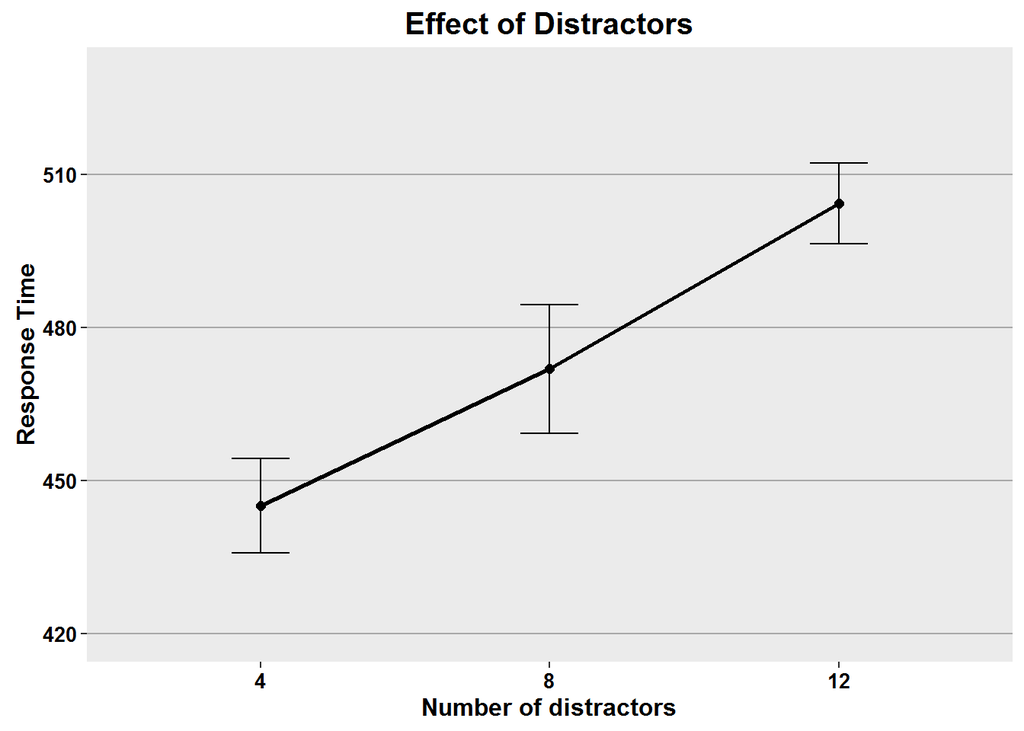

```r
library(ggplot2)
library(gplots)
library(dplyr)

temp<-temp%>%group_by(distractors)%>%
  summarize(means=mean(rt),
            sems=sd(rt)/sqrt(length(rt)))

f<-ggplot(temp, aes(x=as.factor(distractors),
                    y=means,
                    group=1))+
  geom_line(size=1)+
  geom_point(size=2)+
  geom_errorbar(aes(ymax=means+sems,
                    ymin=means-sems),
                width=.2)+
  ggtitle("Effect of Distractors")+
  labs(x="Number of distractors",y="Response Time")+
  theme(plot.title=element_text(size=15,face="bold",vjust=.5))+
  theme(axis.title.x=element_text(size=12,face="bold",vjust=-.25))+
  theme(axis.title.y=element_text(size=12,face="bold",vjust=1))+
  theme(axis.text.x=element_text(size=10,face="bold",color="black"))+
  theme(axis.text.y=element_text(size=10,face="bold",color="black"))+
  coord_cartesian(ylim=c(min(temp$means)-2*max(temp$sems),
                         max(temp$means)+2*max(temp$sems)))+
  theme(panel.border=element_blank(),axis.line=element_line())+
  theme(panel.grid.major.x=element_blank())+
  theme(panel.grid.major.y=element_line(color="darkgrey"))+
  theme(panel.grid.minor.y=element_blank())
f
```

#### The line graph shows that as the number of distractors increases so does the response time.

#### I will now perform a one-way within subject ANOVA.I have to first use the code to get the original data.

```r
temp<-dat[dat$type=="conjunction",]
```

#### Now I will perform the analysis.

```r
summary(aov(rt~distractors+
              Error(subject/distractors),data=temp))
```

```
##
## Error: subject
##           Df Sum Sq Mean Sq F value Pr(>F)
## Residuals  7  15437    2205
##
## Error: subject:distractors
##             Df Sum Sq Mean Sq F value   Pr(>F)
## distractors  2  14078    7039   56.45 1.99e-07 ***
## Residuals   14   1746     125
## ---
## Signif. codes:  0 '***' 0.001 '**' 0.01 '*' 0.05 '.' 0.1 ' ' 1
```

#### The analysis shows that as the distractors increased so did the response time. F(2,14) = 56.45, p < .05

#### I will now conduct a between-subjects ANOVA to identify effects of and interactions between the number of distractions and the search type.

```r
summary(aov(rt~distractors*type, data=dat))
```

```
##                  Df Sum Sq Mean Sq F value  Pr(>F)
## distractors       2   3945    1972   2.648 0.08262 .
## type              1 342239  342239 459.417 < 2e-16 ***
## distractors:type  2  11675    5838   7.836 0.00128 **
## Residuals        42  31288     745
## ---
## Signif. codes:  0 '***' 0.001 '**' 0.01 '*' 0.05 '.' 0.1 ' ' 1
```

#### I will now create a line graph and grouped bar to better understand the analysis, but first I need to summarize the data.

```r
temp<-dat%>%group_by(distractors,type)%>%
  summarize(means=mean(rt),
            sems=sd(rt)/sqrt(length(n)))
```

#### Then I will create the graph and bar.

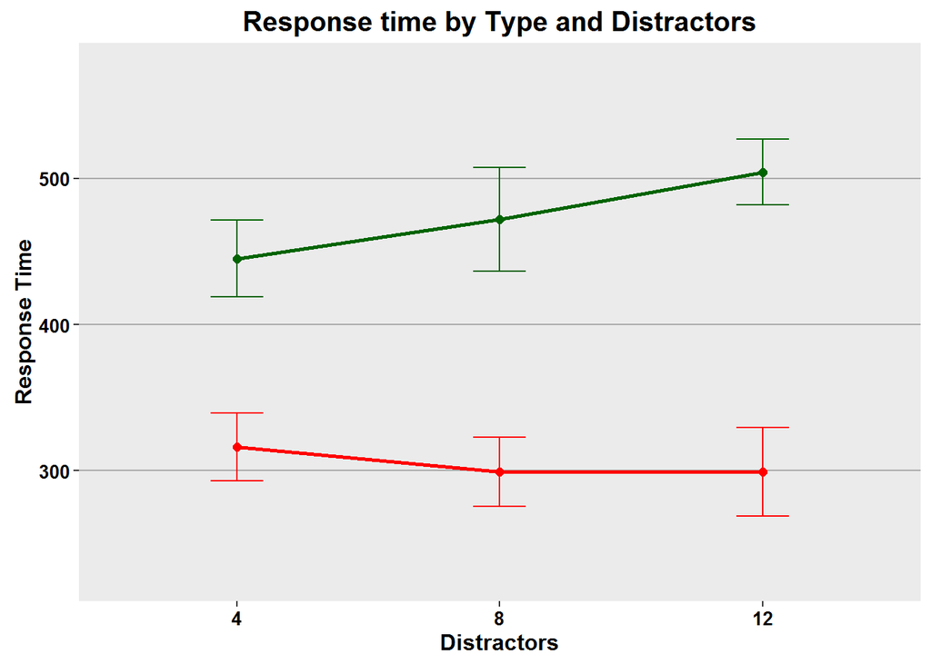

```r
f<-ggplot(temp, aes(x=distractors,
                    y=means,
                    group=type,
                    color=type))+
  geom_line(size=1)+
  geom_point(size=2)+
  scale_color_manual(values=c("darkgreen","red"),
                     name="Type",
                     breaks=c("Conjunction","Feature"),
                     labels=c("Conjunction", "Feature"))+
  geom_errorbar(aes(ymax=means+sems, ymin=means-sems),width=.2)+
  ggtitle("Response time by Type and Distractors")+
  labs(x="Distractors",y="Response Time")+
  theme(plot.title=element_text(size=15,face="bold",vjust=.5))+
  theme(axis.title.x=element_text(size=12,face="bold",vjust=-.25))+
  theme(axis.title.y=element_text(size=12,face="bold",vjust=1))+
  theme(axis.text.x=element_text(size=10,face="bold",color="black"))+
  theme(axis.text.y=element_text(size=10,face="bold",color="black"))+
  coord_cartesian(ylim=c(min(temp$means)-2*max(temp$sems),
                         max(temp$means)+2*max(temp$sems)))+
  theme(panel.border=element_blank(),axis.line=element_line())+
  theme(panel.grid.major.x=element_blank())+
  theme(panel.grid.major.y=element_line(color="darkgrey"))+
  theme(panel.grid.minor.y=element_blank())+
  theme(legend.position=c(.4,.76))+
  theme(legend.background=element_blank())+
  theme(legend.background=element_rect(color="black"))+
  theme(legend.title=element_blank())+
  theme(legend.title=element_text(size=12))+
  theme(legend.title.align=.5)+
  theme(legend.text=element_text(size=10,face="bold"))
f
```

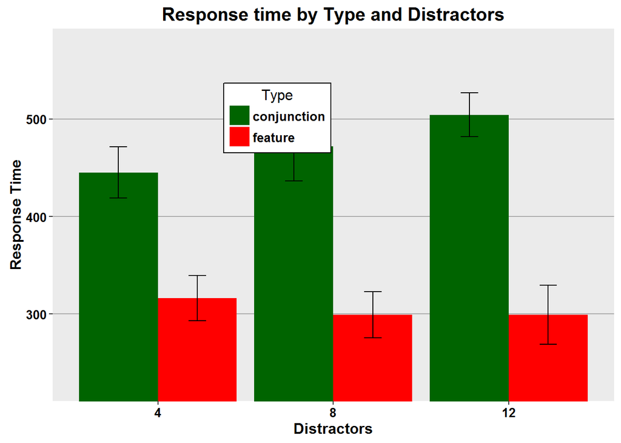

```r
f<-ggplot(temp, aes(x=distractors,
                    y=means,
                    fill=type))+
  geom_bar(stat="identity",position=position_dodge())+
  scale_fill_manual(values=c("darkgreen","red"),
                     name="Type",
                     breaks=c("conjunction","feature"),
                     labels=c("conjunction", "feature"))+
  geom_errorbar(aes(ymax=means+sems,
                    ymin=means-sems),
                width=.2,
                position=position_dodge(.9))+
  ggtitle("Response time by Type and Distractors")+
  labs(x="Distractors",y="Response Time")+
  theme(plot.title=element_text(size=15,face="bold",vjust=.5))+
  theme(axis.title.x=element_text(size=12,face="bold",vjust=-.25))+
  theme(axis.title.y=element_text(size=12,face="bold",vjust=1))+
  theme(axis.text.x=element_text(size=10,face="bold",color="black"))+
  theme(axis.text.y=element_text(size=10,face="bold",color="black"))+
  coord_cartesian(ylim=c(min(temp$means)-2*max(temp$sems),
                         max(temp$means)+2*max(temp$sems)))+
  theme(panel.border=element_blank(),axis.line=element_line())+
  theme(panel.grid.major.x=element_blank())+
  theme(panel.grid.major.y=element_line(color="darkgrey"))+
  theme(panel.grid.minor.y=element_blank())+
  theme(legend.position=c(.4,.76))+
  theme(legend.background=element_blank())+
  theme(legend.background=element_rect(color="black"))+
  theme(legend.title=element_blank())+
  theme(legend.title=element_text(size=12))+
  theme(legend.title.align=.5)+
  theme(legend.text=element_text(size=10,face="bold"))
f
```

#### The figures give an image as to the way the data shows that there is an increase in response time as the number of distractors increases for conjunction, however as the distractors increase for the feature the response time decreases or remains the same.

#### I will now perform a within-subjects two-way ANOVA to examine the effects of and the interactions between number of distractors and search type.

```r
summary(aov(rt~distractors*type+
              Error(subject/(distractors*type)),
                    data=dat))
```

```
##
## Error: subject
##           Df Sum Sq Mean Sq F value Pr(>F)
## Residuals  7  24790    3541
##
## Error: subject:distractors
##             Df Sum Sq Mean Sq F value  Pr(>F)
## distractors  2   3945  1972.3   11.16 0.00127 **
## Residuals   14   2475   176.8
## ---
## Signif. codes:  0 '***' 0.001 '**' 0.01 '*' 0.05 '.' 0.1 ' ' 1
##
## Error: subject:type
##           Df Sum Sq Mean Sq F value  Pr(>F)
## type       1 342239  342239    1626 1.5e-09 ***
## Residuals  7   1473     210
## ---
## Signif. codes:  0 '***' 0.001 '**' 0.01 '*' 0.05 '.' 0.1 ' ' 1
##
## Error: subject:distractors:type
##                  Df Sum Sq Mean Sq F value   Pr(>F)
## distractors:type  2  11675    5838   32.05 5.95e-06 ***
## Residuals        14   2550     182
## ---
## Signif. codes:  0 '***' 0.001 '**' 0.01 '*' 0.05 '.' 0.1 ' ' 1
```

#### The final step is to conduct and interpret the results of a mixed ANOVA in which the number of distractors varies within subjects and the type of search varies between subjects.

```r
summary(aov(rt~distractors*type+
              Error(subject2/distractors),
            data=dat))
```

```
##
## Error: subject2
##           Df Sum Sq Mean Sq F value   Pr(>F)
## type       1 342239  342239   182.4 2.02e-09 ***
## Residuals 14  26263    1876
## ---
## Signif. codes:  0 '***' 0.001 '**' 0.01 '*' 0.05 '.' 0.1 ' ' 1
##
## Error: subject2:distractors
##                  Df Sum Sq Mean Sq F value   Pr(>F)
## distractors       2   3945    1972   10.99    3e-04 ***
## distractors:type  2  11675    5838   32.53 4.98e-08 ***
## Residuals        28   5025     179
## ---
## Signif. codes:  0 '***' 0.001 '**' 0.01 '*' 0.05 '.' 0.1 ' ' 1
```

#### This final analysis shows that the type effects the response time for participants, F(1.14) = 182.4, p <.05. It also shows that distractors effect the response time, F(2,28) = 10.99, p < .05. The analysis does show that there is an interaction between distractors and type, F(2,28) = 32.53, p < .05.